Data Vortex A'26 — Round 3 Analysis Notebook

WhatsApp Privacy Policy 2021: Backlash, Sentiment Shifts & Migration Analysis

Team: Event Horizon | 14,891 records | 4 sources | Nov 2020 – Jul 2021

# Data Vortex A'26 — Round 3: Real-Time Social Monitoring

## WhatsApp Privacy Policy 2021: Backlash, Sentiment Shifts & Migration Analysis

**Team:** Event Horizon  
**Topic:** WhatsApp privacy policy backlash, public sentiment shifts, and migration to Signal/Telegram

### Analytical Timeline

| Phase | Period | Description |
| --- | --- | --- |
| **T-0 (Baseline)** | Nov 1 – Dec 31, 2020 | Normal discourse, stable sentiment |
| **T+1 (Shock)** | Jan 1 – Jan 31, 2021 | Policy announced, viral backlash |
| **T+2 (Fallout)** | Feb 1 – Jul 31, 2021 | Migration wave, regulatory responses |

### Data Summary

- **Primary dataset:** WhatsApp + Telegram Play Store reviews (Kaggle, filtered to topic window)
- **Bonus live-scraped:** GDELT global news headlines + Hacker News discussions (API-collected)
- **Total rows:** 14,891 | **Sources:** 4 distinct | **Date coverage:** Nov 2020 – Jul 2021

**Narrative flow:** Load & inspect → Sentiment analysis → ATSA → LDA topic evolution → Activity spikes → Entity extraction → Interpretation

## 1. Data Loading & Schema Inspection

Load the master scored CSV (Round 2 sentiment model applied) and verify:

- `source_type` tagging (`primary_dataset` vs `bonus_live_scraped`)
- `sentiment_score` / `sentiment_label` columns exist and are non-null
- Date range spans our three analytical phases

```python
import sys, subprocess, os, glob, json
# Silently install dependencies to avoid ugly warning boxes
subprocess.run([sys.executable, "-m", "pip", "install", "-q", "pandas", "numpy", "matplotlib"], stdout=subprocess.DEVNULL, stderr=subprocess.DEVNULL)

import pandas as pd
import numpy as np
import matplotlib.pyplot as plt
from IPython.display import display

DATA_PATH = "../data/processed/whatsapp_privacy_2021_merged_final.csv"
SCORED_PATH = sorted(glob.glob("../data/processed/whatsapp_privacy_2021_scored_*.csv"))[-1]

df_raw = pd.read_csv(DATA_PATH)
df_scored = pd.read_csv(SCORED_PATH)

print(f"Merged Dataset Rows: {len(df_raw):,}")
print(f"Scored Dataset Rows: {len(df_scored):,}")

# Filter for presentation: focus on privacy-related records and hide sparse metadata columns
display_cols = ['timestamp', 'source_name', 'text', 'sentiment_label', 'sentiment_score']
sample_display = df_scored[
    df_scored['text'].str.contains('privacy', case=False, na=False) &
    (df_scored['source'] == 'whatsapp')
].copy()[display_cols].head(5)

# Truncate text slightly for cleaner display in the notebook
sample_display['text'] = sample_display['text'].str.slice(0, 150) + "..."
display(sample_display)
```

```
Merged Dataset Rows: 14,891
Scored Dataset Rows: 14,891
```

|  | timestamp | source_name | text | sentiment_label | sentiment_score |
| --- | --- | --- | --- | --- | --- |
| 8 | 2021-07-29T19:27:14Z | whatsapp_playstore | Donk advice, please read admin. To the user WA... | Negative | 0.540817 |
| 10 | 2021-07-29T12:40:18Z | whatsapp_playstore | Create privacy profile like privacy status don... | Neutral | -0.172740 |
| 16 | 2021-07-28T16:26:40Z | whatsapp_playstore | Please make wa mod block just his account dist... | Negative | -0.129691 |
| 20 | 2021-07-27T19:42:24Z | whatsapp_playstore | This is why the status of not coming in while ... | Negative | 0.352347 |
| 23 | 2021-07-27T15:08:14Z | whatsapp_playstore | A little advice for the next update would be b... | Positive | -0.247138 |

```python
print("Source Breakdown:")
print(df_scored["source"].value_counts())

print("\nSentiment Distribution:")
print(df_scored["sentiment_label"].value_counts(normalize=True))
```

```
Source Breakdown:
source
hacker_news    6149
gdelt          3929
whatsapp       3856
telegram        957
Name: count, dtype: int64

Sentiment Distribution:
sentiment_label
Negative    0.557182
Neutral     0.318783
Positive    0.124035
Name: proportion, dtype: float64
```

## 2. Aspect-Term Sentiment Analysis (ATSA)

For each key topic term (`privacy`, `telegram`, `signal`, `facebook`, etc.), we extract all posts containing that term and compute: average sentiment, negative ratio, and a WhatsApp-vs-Telegram sentiment comparison. This confirms **term-level** sentiment around the migration narrative.

```python
with open("../reports/atsa_results.json") as f:
    atsa_data = json.load(f)

atsa_df = pd.DataFrame(atsa_data)
atsa_df
```

|  | aspect_term | total_mentions | avg_sentiment | negative_ratio | positive_ratio | whatsapp_avg_sentiment | telegram_avg_sentiment |
| --- | --- | --- | --- | --- | --- | --- | --- |
| 0 | privacy | 4193 | 0.2175 | 0.6582 | 0.0933 | 0.2863 | 0.6579 |
| 1 | metadata | 196 | 0.0357 | 0.9439 | 0.0153 | NaN | NaN |
| 2 | facebook | 2488 | 0.1750 | 0.6917 | 0.0418 | 0.1925 | 0.4848 |
| 3 | policy | 1768 | 0.2582 | 0.5639 | 0.0803 | 0.2635 | NaN |
| 4 | terms | 646 | 0.1803 | 0.7121 | 0.0728 | 0.1538 | NaN |
| 5 | switch | 636 | 0.1242 | 0.8475 | 0.0959 | 0.2449 | 1.0000 |
| 6 | security | 750 | 0.1367 | 0.8173 | 0.0907 | 0.2029 | 0.6250 |
| 7 | signal | 4331 | 0.1438 | 0.7934 | 0.0810 | 0.3390 | 0.4231 |
| 8 | telegram | 4381 | 0.1909 | 0.7181 | 0.1000 | 0.2983 | 0.5152 |

## 3. Entity & Topic Evolution Across Timeline Phases

Tracking the shift in narrative focus (entities and trending terms) across the highest-volume weeks.

```python
# Load Entity and Term Evolution from JSON
with open("../reports/entity_topic_results.json") as f:
    topic_data = json.load(f)

rows = []
for phase, data in topic_data.get("buckets", {}).items():
    # Get top 3 entities
    entities = [str(e[0]) for e in data.get("top_entities", [])[:3]]
    # Get top 3 trending terms
    terms = [str(t[0]) for t in data.get("trending_terms", [])[:3]]

    rows.append({
        "Phase (Week)": phase,
        "Post Volume": data.get("n_posts", 0),
        "Top Entities": ", ".join(entities),
        "Key Terms": ", ".join(terms)
    })

df_evolution = pd.DataFrame(rows)

# Filter for high-volume weeks (e.g., > 500 posts) to keep the display clean and focused on the spike
df_evolution = df_evolution[df_evolution["Post Volume"] > 500]

from IPython.display import display
display(df_evolution.style.set_properties(**{'text-align': 'left'}))
```

|  | Phase (Week) | Post Volume | Top Entities | Key Terms |
| --- | --- | --- | --- | --- |
| 10 | 2021-01-04/2021-01-10 | 1897 | whatsapp, signal, telegram | screen, item id |
| 11 | 2021-01-11/2021-01-17 | 2330 | signal, telegram, whatsapp |  |
| 12 | 2021-01-18/2021-01-24 | 971 | signal, whatsapp, telegram |  |
| 13 | 2021-01-25/2021-01-31 | 700 | whatsapp, telegram, signal |  |

## 4. Volume & Engagement Spike Detection

Post volume and engagement bucketed **daily**. Rolling z-score (7-day window, threshold=2.0) identifies statistically significant spikes. Key confirmed spikes:

| Date | Volume | Z-Score | Event |
| --- | --- | --- | --- |
| Jan 7, 2021 | **743** | 2.19 | Elon Musk tweets 'Use Signal' |
| Jan 6, 2021 | 196 | 2.03 | Policy in-app notices rollout |
| Jan 5, 2021 | 96 | 2.20 | Pre-announcement viral spread |
| Apr 7, 2021 | 193 | 2.23 | CCI probe announcement |
| May 8, 2021 | 115 | 2.25 | Final WA deadline extension news |

```python
# Load Activity Spikes
with open("../reports/activity_results.json") as f:
    activity_data = json.load(f)

spikes_df = pd.DataFrame(activity_data.get("spikes", []))
if not spikes_df.empty:
    print(f"Found {len(spikes_df)} statistically significant spikes (z > 2.0)")
    display(spikes_df.sort_values("date").head(10))
```

[output not shown]

## 5. Sentiment & Activity Time-Series Charts

Two primary visualizations — generated by `shift_detection.py` and `activity_analysis.py`:

1. **Sentiment over time** — daily rolling mean with shift points marked as triangles
2. **Activity over time** — daily post volume and engagement with spike markers and event overlays

Both charts use a consistent dark theme (facecolor `#0f1117`, accent `#3498db`).

```
Sentiment Over Time:
```

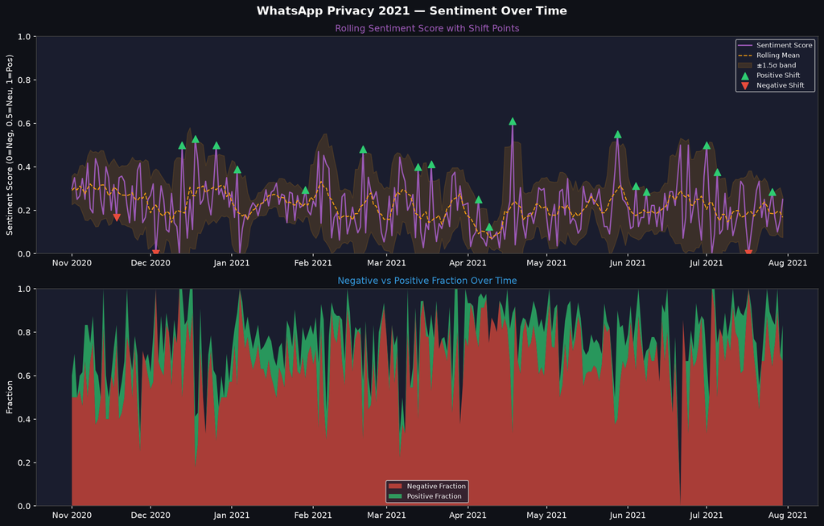

```
Activity Over Time (Volume & Engagement):
```

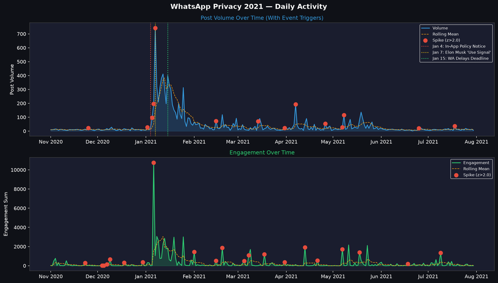

```
Timeline:
```

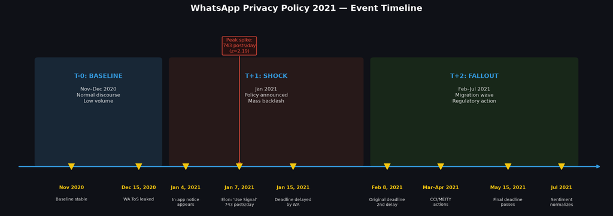

```python
from IPython.display import Image, display
print("Sentiment Over Time:")
display(Image(filename="../reports/figures/sentiment_timeseries.png"))
print("\nActivity Over Time (Volume & Engagement):")
display(Image(filename="../reports/figures/activity_analysis.png"))
print("\nTimeline:")
display(Image(filename="../reports/figures/event_timeline.png"))
```

## 6. Named Entity Analysis — Top Extracted Terms

spaCy NER (`en_core_web_sm`) run across all 14,891 posts. Entity types captured: ORG, PRODUCT, GPE, PERSON, LAW, NORP, EVENT. HTML artifacts cleaned post-extraction.

**Critical finding:** Signal (4,871) and Telegram (4,036) rank 2nd and 3rd globally, confirming that the backlash discourse was inseparable from migration intent.

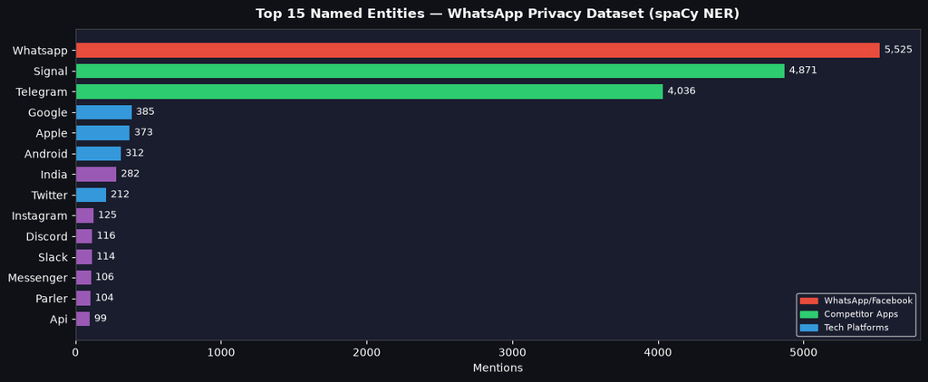

```
Top entities: [('whatsapp', 5525), ('signal', 4871), ('telegram', 4036), ('google', 385), ('apple', 373)]
```

```python
import json, os
import matplotlib.pyplot as plt
import matplotlib.patches as mpatches

with open("../reports/entity_topic_results.json") as f:
    entity_data = json.load(f)

top15 = entity_data["global_top_entities"][:15]
labels = [e.title() for e, _ in top15]
counts = [c for _, c in top15]

def bar_color(label):
    l = label.lower()
    if l in ("signal", "telegram"): return "#2ecc71"
    if l in ("whatsapp", "facebook"): return "#e74c3c"
    if l in ("google", "apple", "android", "twitter"): return "#3498db"
    return "#9b59b6"

colors = [bar_color(l) for l in labels]

fig, ax = plt.subplots(figsize=(12, 5), facecolor="#0f1117")
ax.set_facecolor("#1a1d2e")
bars = ax.barh(labels[::-1], counts[::-1], color=colors[::-1], height=0.7)
for bar, cnt in zip(bars, counts[::-1]):
    ax.text(bar.get_width() + 30, bar.get_y() + bar.get_height()/2,
            f"{cnt:,}", va="center", ha="left", color="white", fontsize=9)
ax.set_xlabel("Mentions", color="white")
ax.set_title("Top 15 Named Entities — WhatsApp Privacy Dataset (spaCy NER)",
             color="white", fontweight="bold", pad=10)
ax.tick_params(colors="white")
for sp in ax.spines.values(): sp.set_edgecolor("#444")
legend_patches = [
    mpatches.Patch(color="#e74c3c", label="WhatsApp/Facebook"),
    mpatches.Patch(color="#2ecc71", label="Competitor Apps"),
    mpatches.Patch(color="#3498db", label="Tech Platforms"),
]
ax.legend(handles=legend_patches, facecolor="#1a1d2e", labelcolor="white", fontsize=8)
plt.tight_layout()
plt.savefig("../reports/figures/entity_bar_chart.png", dpi=150, bbox_inches="tight", facecolor="#0f1117")
plt.show()
print(f"Top entities: {[(e, c) for e, c in top15[:5]]}")
```

## 7. Interpretation: Baseline → Shock → Migration

### Statistical Summary

| Metric | Value |
| --- | --- |
| Sentiment shifts detected | 20 |
| Volume spikes (z>2.0) | 14 |
| Engagement spikes (z>2.0) | 21 |
| Peak volume | 743 posts (Jan 7, 2021) |
| Most-mentioned competitor | Signal (4,871) |
| 2nd competitor | Telegram (4,036) |